# Notebook

**Mehr zum Trainingsprozess**

Dr. Matthias Hölzl

## Daten

- 10 Datensätze mit 1 Merkmal
- Jedes Merkmal ist eine Zahl zwischen 0.5 und 9.0
- Zu jedem Datensatz gehört ein Label (2.1 bis 19.2)

```python
data_x = [0.5, 1.4, 2.1, 3.5, 4.2, 5.1, 6.3, 7.6, 8.2, 9.0]
data_y = [2.1, 3.5, 5.8, 7.1, 9.3, 11.5, 13.2, 16.0, 17.1, 19.2]
```

```python
assert len(data_x) == len(data_y)
print(f"We have {len(data_x)} labeled data points.")
```

```
We have 10 labeled data points.
```

## Visualisierung der Daten

```python
import matplotlib.pyplot as plt
```

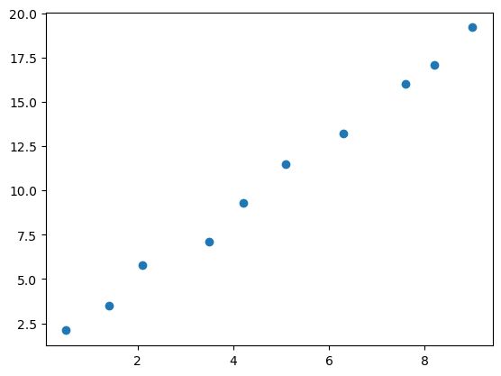

```python
plt.scatter(data_x, data_y)
plt.show()
```

## Aufteilen der Daten in Trainings- und Testdaten

- Nach dem Training muss das Modell bewertet werden
- Die Bewertung muss auf anderen Daten basieren als das Training
- Andernfalls könnte der Lernende nur die Beispiele speichern, die er gesehen hat
- Uns interessiert aber wie gut das Modell auf neuen Daten funktioniert (generalisiert)

```python
# Splitting the data: 6 for training, 4 for testing
train_x = [[x] for x in data_x[:6]]
train_y = data_y[:6]
train_x, train_y
```

```
([[0.5], [1.4], [2.1], [3.5], [4.2], [5.1]], [2.1, 3.5, 5.8, 7.1, 9.3, 11.5])
```

```python
test_x = [[x] for x in data_x[6:]]
test_y = data_y[6:]
test_x, test_y
```

```
([[6.3], [7.6], [8.2], [9.0]], [13.2, 16.0, 17.1, 19.2])
```

```python
print(f"Training samples: {len(train_x)}")
print(f"Test samples: {len(test_x)}")
```

```
Training samples: 6
Test samples: 4
```

## Trainieren des Modells

```python
from sklearn.linear_model import LinearRegression
```

```python
model = LinearRegression()
```

```python
try:
    print(model.coef_, model.intercept_)
except AttributeError:
    print("Model is not fitted yet.")
```

```
Model is not fitted yet.
```

```python
model.fit(train_x, train_y)
```

```
LinearRegression()
```

```python
model.coef_, model.intercept_
```

```
(array([1.97997416]), np.float64(1.0060723514211878))
```

## Bewerten des Modells

Reproduktion der Trainingsdaten:

```python
train_predictions = model.predict(train_x)
train_predictions
```

```
array([ 1.99605943,  3.77803618,  5.16401809,  7.93598191,  9.32196382,
       11.10394057])
```

Wie groß sind die Abweichungen?

```python
for pred, actual in zip(train_predictions, train_y):
    print(f"Predicted: {pred:.2f}, Actual: {actual:.2f}")
```

```
Predicted: 2.00, Actual: 2.10
Predicted: 3.78, Actual: 3.50
Predicted: 5.16, Actual: 5.80
Predicted: 7.94, Actual: 7.10
Predicted: 9.32, Actual: 9.30
Predicted: 11.10, Actual: 11.50
```

Totaler absoluter Fehler:

```python
total_absolute_error_train = sum(
    abs(pred - actual) for pred, actual in zip(train_predictions, train_y)
)
```

```python
total_absolute_error_train
```

```
np.float64(2.271963824289406)
```

Totaler quadratischer Fehler:

```python
total_squared_error_train = sum(
    (pred - actual) ** 2 for pred, actual in zip(train_predictions, train_y)
)
```

```python
total_squared_error_train
```

```
np.float64(1.348791989664082)
```

Problem: Größe des Fehlers hängt von der Anzahl der Werte ab!

```python
few_values = [(n, n + 1) for n in range(1, 11)]
many_values = [(n, n + 1) for n in range(1, 1001)]
```

Absoluter Fehler:

```python
total_absolute_error_few = sum(abs(pred - actual) for pred, actual in few_values)
```

```python
total_absolute_error_few
```

```
10
```

```python
total_absolute_error_many = sum(abs(pred - actual) for pred, actual in many_values)
```

```python
total_absolute_error_many
```

```
1000
```

Besser: Fehler pro Wert

Durchschnittlicher absoluter Fehler (MAE - Mean Absolute Error):

```python
total_absolute_error_train / len(train_y)
```

```
np.float64(0.3786606373815677)
```

Durchschnittlicher quadratischer Fehler (MSE - Mean Squared Error)

```python
total_squared_error_train / len(train_y)
```

```
np.float64(0.22479866494401368)
```

Die durchschnittliche absolute Fehler sagt, wie weit jeder vorhergesagte Wert im Durchschnitt vom echten Wert abweicht:

```python
total_absolute_error_few / len(few_values)
```

```
1.0
```

```python
total_absolute_error_many / len(many_values)
```

```
1.0
```

- Der durchschnittliche quadratische Fehler gibt die durchschnittliche quadratische Abweichung an.
- Dadurch werden größere Abweichungen stärker gewichtet, kleine Abweichungen weniger stark.

```python
total_absolute_error_few / len(few_values)
```

```
1.0
```

```python
total_absolute_error_many / len(many_values)
```

```
1.0
```

```python
small_errors = [(n, n + 0.1) for n in range(1, 11)]
large_errors = [(n, n + 10) for n in range(1, 11)]
```

```python
sum((pred - actual) ** 2 for pred, actual in small_errors) / len(small_errors)
```

```
0.009999999999999953
```

```python
sum((pred - actual) ** 2 for pred, actual in large_errors) / len(large_errors)
```

```
100.0
```

## Bewerten des Modells

Wir sehen uns an, wie gut das Modell die Testdaten vorhersagen kann, die es noch nicht gesehen hat:

```python
predictions = model.predict(test_x)
predictions
```

```
array([13.47990956, 16.05387597, 17.24186047, 18.82583979])
```

```python
for pred, actual in zip(predictions, test_y):
    print(f"Predicted: {pred:.2f}, Actual: {actual:.2f}")
```

```
Predicted: 13.48, Actual: 13.20
Predicted: 16.05, Actual: 16.00
Predicted: 17.24, Actual: 17.10
Predicted: 18.83, Actual: 19.20
```

```python
mean_absolute_error_test = sum(
    abs(pred - actual) for pred, actual in zip(predictions, test_y)
) / len(test_y)
mean_absolute_error_test
```

```
np.float64(0.21245155038759744)
```

```python
mean_squared_error_test = sum(
    (pred - actual) ** 2 for pred, actual in zip(predictions, test_y)
) / len(test_y)
mean_squared_error_test
```

```
np.float64(0.06034305851845125)
```

```python
x_plot = list(range(11))
x_pred = [[x] for x in x_plot]
```

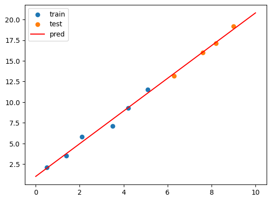

```python
plt.scatter(train_x, train_y, label="train")
plt.scatter(test_x, test_y, label="test")
plt.plot(x_plot, model.predict(x_pred), color="red", label="pred")
plt.legend()
```

## Workshop: Pizza-Lieferzeit

In diesem Workshop werden wir ein einfaches Machine Learning Modell trainieren, um die Lieferzeit einer Pizza basierend auf der Entfernung vom Restaurant vorherzusagen.

Die Daten sind bereits vorbereitet:

- `pizza_distance`: Entfernung vom Restaurant in km
- `pizza_time`: Lieferzeit in Minuten

```python
pizza_distance = [
    1.0,
    1.5,
    2.0,
    2.5,
    3.0,
    3.5,
    4.0,
    4.5,
    5.0,
    5.5,
    6.0,
    6.5,
    7.0,
    7.5,
    8.0,
]
```

```python
pizza_time = [15, 18, 20, 23, 25, 28, 30, 33, 35, 38, 40, 43, 45, 48, 50]
```

```python
pizza_distance[:5]
```

```
[1.0, 1.5, 2.0, 2.5, 3.0]
```

```python
pizza_time[:5]
```

```
[15, 18, 20, 23, 25]
```

Visualisieren Sie die Daten in einem Scatterplot, um die Beziehung zwischen Entfernung und Lieferzeit zu sehen.

```python
import matplotlib.pyplot as plt
```

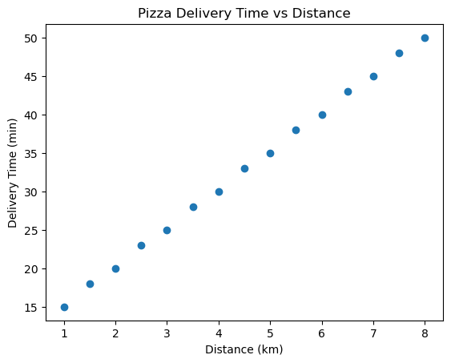

```python
plt.scatter(pizza_distance, pizza_time)
plt.xlabel("Distance (km)")
plt.ylabel("Delivery Time (min)")
plt.title("Pizza Delivery Time vs Distance")
plt.show()
```

Teilen Sie die Daten in Trainings- und Testdaten auf.

- Verwenden Sie ca. 60% der Daten für das Training und ca. 40% für den Test
- Denken Sie daran, dass das Modell erwartet, dass die Features in einer 2D-Liste sind (Liste von Listen)

```python
pizza_x = [[d] for d in pizza_distance]
```

```python
pizza_x_train = pizza_x[:9]
pizza_y_train = pizza_time[:9]

pizza_x_test = pizza_x[9:]
pizza_y_test = pizza_time[9:]
```

```python
print(f"Training samples: {len(pizza_x_train)}")
print(f"Test samples: {len(pizza_x_test)}")
```

```
Training samples: 9
Test samples: 6
```

```python
pizza_x_train[:3], pizza_y_train[:3]
```

```
([[1.0], [1.5], [2.0]], [15, 18, 20])
```

Trainieren Sie ein lineares Regressionsmodell mit den Trainingsdaten.

```python
from sklearn.linear_model import LinearRegression
```

```python
model = LinearRegression()
model.fit(pizza_x_train, pizza_y_train)
```

```
LinearRegression()
```

```python
print(f"Coefficient (slope): {model.coef_[0]:.2f}")
print(f"Intercept: {model.intercept_:.2f}")
```

```
Coefficient (slope): 5.00
Intercept: 10.22
```

Bewerten Sie das Modell mit dem Mean Absolute Error (MAE) und dem Mean Squared Error (MSE) sowohl für die Trainings- als auch für die Testdaten.

```python
train_predictions = model.predict(pizza_x_train)
test_predictions = model.predict(pizza_x_test)
```

```python
def mean_absolute_error(y_true, y_pred):
    return sum(abs(a - b) for a, b in zip(y_true, y_pred)) / len(y_true)
```

```python
def mean_squared_error(y_true, y_pred):
    return sum((a - b) ** 2 for a, b in zip(y_true, y_pred)) / len(y_true)
```

```python
print(f"Training MAE: {mean_absolute_error(pizza_y_train, train_predictions):.2f}")
print(f"Training MSE: {mean_squared_error(pizza_y_train, train_predictions):.2f}")
```

```
Training MAE: 0.25
Training MSE: 0.06
```

```python
print(f"Test MAE: {mean_absolute_error(pizza_y_test, test_predictions):.2f}")
print(f"Test MSE: {mean_squared_error(pizza_y_test, test_predictions):.2f}")
```

```
Test MAE: 0.25
Test MSE: 0.06
```

Erstellen Sie einen Plot, der zeigt, wie das Modell die Beziehung zwischen Entfernung und Lieferzeit gelernt hat:

- Plotten Sie die Originaldaten als Scatterplot
- Plotten Sie die Vorhersagen des Modells als Linie

```python
# Create a range of distances for plotting the model's predictions
distance_range = [[x] for x in range(10)]
```

```python
time_predictions = model.predict(distance_range)
```

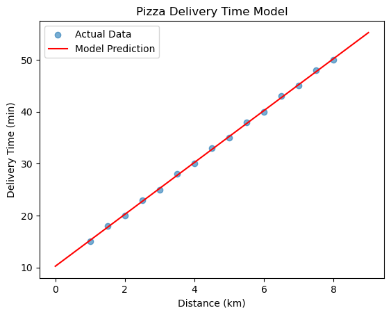

```python
plt.scatter(pizza_distance, pizza_time, label="Actual Data", alpha=0.6)
plt.plot(distance_range, time_predictions, color="red", label="Model Prediction")
plt.xlabel("Distance (km)")
plt.ylabel("Delivery Time (min)")
plt.title("Pizza Delivery Time Model")
plt.legend()
plt.show()
```

Verwenden Sie das Modell, um die Lieferzeit für neue Entfernungen vorherzusagen:

- 2.8 km
- 5.2 km
- 9.0 km

```python
new_distances = [[2.8], [5.2], [9.0]]
new_predictions = model.predict(new_distances)
```

```python
for distance, time in zip(new_distances, new_predictions):
    print(f"Distance: {distance[0]} km → Predicted delivery time: {time:.1f} min")
```

```
Distance: 2.8 km → Predicted delivery time: 24.2 min
Distance: 5.2 km → Predicted delivery time: 36.2 min
Distance: 9.0 km → Predicted delivery time: 55.2 min
```